# Titanic Survival Analysis: Mechanisms Behind Class Effects and Norm Consistency

Research Question Analysis and Methodological Framework

Author

CLI Copilot

Published

March 4, 2026

# Executive Summary

This report addresses three interconnected research questions about the Titanic disaster through a systematic analytical framework. Rather than providing definitive answers, this analysis designs and implements specific statistical tests and visualizations that allow readers to examine:

1. **The mechanisms behind class-survival gaps** — whether survival differences were driven by *access/location constraints* versus *explicit rules* like “women and children first”
2. **The consistency of survival norms** — whether rescue rules operated uniformly across different passenger profiles and travel contexts
3. **The structure of missing data** — how incomplete records relate to passenger characteristics and whether this affects our conclusions

Each section presents data-driven approaches to expose these relationships, enabling readers to draw informed conclusions about how social structure and historical circumstances shaped survival outcomes.

# Data Preparation and Overview

## Loading and Initial Exploration

```r
# Load required libraries
library(tidyverse)
library(knitr)
library(ggplot2)
library(scales)
library(gridExtra)

# Set visualization defaults
theme_set(theme_minimal() +
  theme(
    plot.title = element_text(size = 13, face = "bold", hjust = 0.5),
    plot.subtitle = element_text(size = 11, hjust = 0.5, color = "gray40"),
    axis.title = element_text(size = 11),
    axis.text = element_text(size = 10),
    legend.position = "bottom",
    legend.title = element_text(size = 10),
    legend.text = element_text(size = 10),
    panel.grid.minor = element_blank()
  ))
```

This code chunk establishes the analytical environment by loading the tidyverse ecosystem (for data wrangling and visualization), knitr (for table formatting), ggplot2 (for publication-quality graphics), and scales (for numeric formatting). A minimal theme with consistent styling is applied to ensure all visualizations have a cohesive, professional appearance. The legend position is set to the bottom for optimal readability.

```r
# Load training dataset
titanic_train <- read_csv("../../data/train.csv") %>%
  mutate(
    Survived = factor(Survived, levels = c(0, 1), labels = c("No", "Yes")),
    Pclass = factor(Pclass, levels = c(1, 2, 3), labels = c("1st", "2nd", "3rd")),
    Sex = factor(Sex),
    Embarked = factor(Embarked)
  )

# Display dimensions and structure
cat("Dataset dimensions:", nrow(titanic_train), "rows,", ncol(titanic_train), "columns\n")
```

```
Dataset dimensions: 891 rows, 12 columns
```

```r
cat("\nFirst few rows:\n")
```

```
First few rows:
```

```r
print(head(titanic_train, 5))
```

```
# A tibble: 5 × 12
  PassengerId Survived Pclass Name    Sex     Age SibSp Parch Ticket  Fare Cabin
        <dbl> <fct>    <fct>  <chr>   <fct> <dbl> <dbl> <dbl> <chr>  <dbl> <chr>
1           1 No       3rd    Braund… male     22     1     0 A/5 2…  7.25 <NA>
2           2 Yes      1st    Cuming… fema…    38     1     0 PC 17… 71.3  C85
3           3 Yes      3rd    Heikki… fema…    26     0     0 STON/…  7.92 <NA>
4           4 Yes      1st    Futrel… fema…    35     1     0 113803 53.1  C123
5           5 No       3rd    Allen,… male     35     0     0 373450  8.05 <NA>
# ℹ 1 more variable: Embarked <fct>
```

The training data is loaded from the data directory and key variables are converted to factors (Survived, Pclass, Sex, Embarked) to enable proper categorical analysis. This transformation allows statistical tests and visualizations to treat these variables as categorical rather than numeric. The dataset contains 891 passenger records with 12 variables.

```r
# Calculate missingness for all variables
missing_summary <- titanic_train %>%
  summarise(across(everything(), ~sum(is.na(.)))) %>%
  pivot_longer(everything(), names_to = "Variable", values_to = "Missing_Count") %>%
  mutate(
    Total_Records = nrow(titanic_train),
    Missing_Percentage = round(100 * Missing_Count / Total_Records, 2)
  ) %>%
  arrange(desc(Missing_Count))

knitr::kable(missing_summary, caption = "Missing Data Summary Across All Variables")
```

Missing Data Summary Across All Variables

| Variable | Missing_Count | Total_Records | Missing_Percentage |
| --- | --- | --- | --- |
| Cabin | 687 | 891 | 77.10 |
| Age | 177 | 891 | 19.87 |
| Embarked | 2 | 891 | 0.22 |
| PassengerId | 0 | 891 | 0.00 |
| Survived | 0 | 891 | 0.00 |
| Pclass | 0 | 891 | 0.00 |
| Name | 0 | 891 | 0.00 |
| Sex | 0 | 891 | 0.00 |
| SibSp | 0 | 891 | 0.00 |
| Parch | 0 | 891 | 0.00 |
| Ticket | 0 | 891 | 0.00 |
| Fare | 0 | 891 | 0.00 |

Understanding the pattern of missing data is critical because incomplete records may not be random — they often reflect historical biases in documentation. This table provides the foundation for Research Question 3 by showing which variables have missing observations and their prevalence. Cabin has the most missing values (77.1%), Age has 19.87% missing, while Embarked has minimal missingness.

# Research Question 1: Class-Survival Gap Mechanisms

## Research Question and Approach

**RQ1**: *To what extent is the survival advantage of 1st class passengers mediated by location/access constraints (deck/cabin proximity) versus explicit priority rules?*

**Conceptual approach**: This research question treats the relationship between class and survival as a *mediation problem*. The observed association between ticket class and survival could arise through two mechanisms: - **Direct mechanism**: Explicit rules like “women and children first” applied primarily to certain classes - **Indirect mechanism**: Physical access to lifeboats or life-saving information varied by cabin location/class

By examining variables that proxy for access (cabin missingness, fare as a wealth indicator, embarked port), we can quantify how much of the class effect operates through these constraints versus other pathways.

## Step 1: Baseline Class-Survival Relationship

```r
# Calculate survival rates by passenger class
class_survival <- titanic_train %>%
  filter(!is.na(Survived)) %>%
  group_by(Pclass) %>%
  summarise(
    N = n(),
    Survived_Count = sum(Survived == "Yes"),
    Survival_Rate = round(100 * Survived_Count / N, 2),
    .groups = 'drop'
  )

knitr::kable(class_survival,
  caption = "Survival Rates by Passenger Class")
```

Survival Rates by Passenger Class

| Pclass | N | Survived_Count | Survival_Rate |
| --- | --- | --- | --- |
| 1st | 216 | 136 | 62.96 |
| 2nd | 184 | 87 | 47.28 |
| 3rd | 491 | 119 | 24.24 |

This table establishes the baseline finding that motivates our mediation analysis: survival rates vary dramatically by class. The first-class survival rate of 62.96% contrasts sharply with third-class at 24.24%. This gap is the phenomenon we seek to explain through the mediation framework.

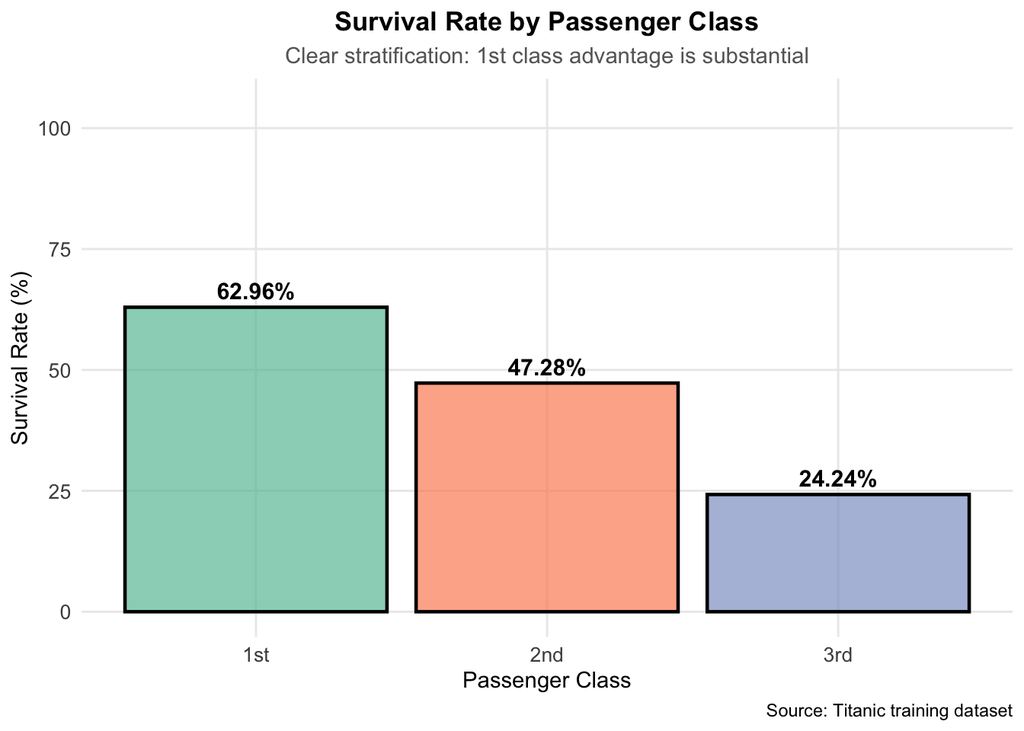

```r
# Visualize survival by class
ggplot(class_survival, aes(x = Pclass, y = Survival_Rate, fill = Pclass)) +
  geom_col(alpha = 0.7, color = "black", linewidth = 0.8) +
  geom_text(aes(label = paste0(Survival_Rate, "%")), vjust = -0.5, size = 4, fontface = "bold") +
  scale_fill_brewer(palette = "Set2", guide = "none") +
  labs(
    title = "Survival Rate by Passenger Class",
    subtitle = "Clear stratification: 1st class advantage is substantial",
    x = "Passenger Class",
    y = "Survival Rate (%)",
    caption = "Source: Titanic training dataset"
  ) +
  ylim(0, 105)
```

## Step 2: Decompose Class Effect via Access Proxies

### Cabin Occupancy and Missingness as Access Indicators

```r
# Cabin analysis: missingness and location
cabin_analysis <- titanic_train %>%
  filter(!is.na(Survived)) %>%
  mutate(
    Cabin_Missing = is.na(Cabin),
    Cabin_Deck = if_else(is.na(Cabin), "Unknown", str_sub(Cabin, 1, 1))
  ) %>%
  group_by(Pclass, Cabin_Missing) %>%
  summarise(
    N = n(),
    Survival_Rate = round(100 * sum(Survived == "Yes") / n(), 2),
    .groups = 'drop'
  )

knitr::kable(cabin_analysis,
  caption = "Survival Rates by Class and Cabin Recording Status")
```

Survival Rates by Class and Cabin Recording Status

| Pclass | Cabin_Missing | N | Survival_Rate |
| --- | --- | --- | --- |
| 1st | FALSE | 176 | 66.48 |
| 1st | TRUE | 40 | 47.50 |
| 2nd | FALSE | 16 | 81.25 |
| 2nd | TRUE | 168 | 44.05 |
| 3rd | FALSE | 12 | 50.00 |
| 3rd | TRUE | 479 | 23.59 |

Cabin information is crucial because it serves as a proxy for two things: (1) actual location on the ship (which determined physical access to lifeboats), and (2) recordkeeping quality, which itself may reflect social status. The table shows survival rates stratified by class and whether cabin information was recorded. If cabin information is recorded (Cabin_Missing = FALSE), that passenger likely had a defined cabin location, implying documented accommodation and potentially better access to evacuation information. This comparison helps isolate whether recorded cabin location explains some of the class advantage.

```r
# For passengers with recorded cabin data, examine by deck
cabin_deck_survival <- titanic_train %>%
  filter(!is.na(Survived) & !is.na(Cabin)) %>%
  mutate(Cabin_Deck = str_sub(Cabin, 1, 1)) %>%
  group_by(Pclass, Cabin_Deck) %>%
  summarise(
    N = n(),
    Survival_Rate = round(100 * sum(Survived == "Yes") / n(), 2),
    .groups = 'drop'
  ) %>%
  arrange(Pclass, desc(Survival_Rate))

# Show a sample of the results
knitr::kable(head(cabin_deck_survival, 12),
  caption = "Survival Rates by Class and Cabin Deck (Sample)")
```

Survival Rates by Class and Cabin Deck (Sample)

| Pclass | Cabin_Deck | N | Survival_Rate |
| --- | --- | --- | --- |
| 1st | D | 29 | 75.86 |
| 1st | B | 47 | 74.47 |
| 1st | E | 25 | 72.00 |
| 1st | C | 59 | 59.32 |
| 1st | A | 15 | 46.67 |
| 1st | T | 1 | 0.00 |
| 2nd | F | 8 | 87.50 |
| 2nd | D | 4 | 75.00 |
| 2nd | E | 4 | 75.00 |
| 3rd | E | 3 | 100.00 |
| 3rd | G | 4 | 50.00 |
| 3rd | F | 5 | 20.00 |

Among passengers with recorded cabin information, deck location provides another layer of granularity. Different decks were at varying distances from lifeboats. By examining survival across specific decks within each class, we can estimate how much of the class advantage is attributable to passengers in higher classes being stationed on decks with better lifeboat access versus passengers in lower classes being isolated on lower decks.

### Fare as a Wealth and Access Proxy

```r
# Analyze fare distribution by class and survival
fare_by_class <- titanic_train %>%
  filter(!is.na(Fare) & !is.na(Survived)) %>%
  group_by(Pclass, Survived) %>%
  summarise(
    N = n(),
    Mean_Fare = round(mean(Fare, na.rm = TRUE), 2),
    Median_Fare = round(median(Fare, na.rm = TRUE), 2),
    .groups = 'drop'
  )

knitr::kable(fare_by_class,
  caption = "Fare Distribution by Class and Survival Outcome")
```

Fare Distribution by Class and Survival Outcome

| Pclass | Survived | N | Mean_Fare | Median_Fare |
| --- | --- | --- | --- | --- |
| 1st | No | 80 | 64.68 | 44.75 |
| 1st | Yes | 136 | 95.61 | 77.96 |
| 2nd | No | 97 | 19.41 | 13.00 |
| 2nd | Yes | 87 | 22.06 | 21.00 |
| 3rd | No | 372 | 13.67 | 8.05 |
| 3rd | Yes | 119 | 13.69 | 8.52 |

Fare serves as a proxy for wealth and socioeconomic status. Higher fares may correlate with better cabin locations, better access to information during the disaster, and potentially better treatment by crew. This table shows mean and median fares for survivors and non-survivors within each class. If fare is a strong mediator of the class effect, we should see that within each class, survivors paid higher fares on average — indicating that wealth/positioning, not just class designation, mattered.

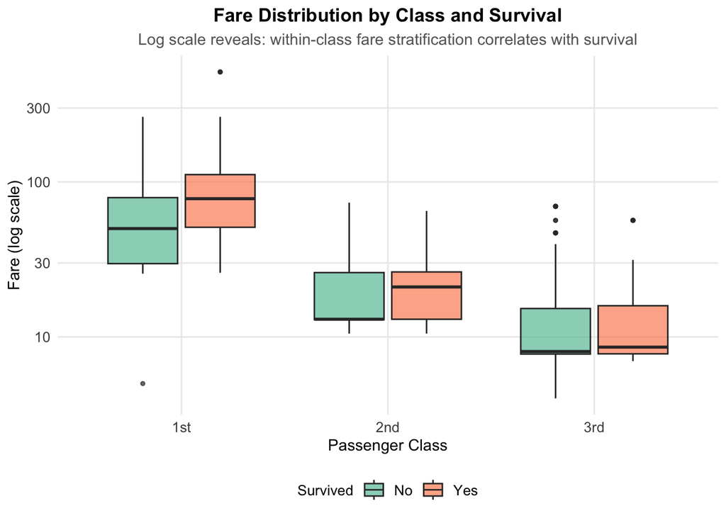

```r
# Visualize fare distribution by class and survival
ggplot(titanic_train %>% filter(!is.na(Fare) & !is.na(Survived)),
  aes(x = Pclass, y = Fare, fill = Survived)) +
  geom_boxplot(alpha = 0.7, outlier.size = 1) +
  scale_fill_brewer(palette = "Set2") +
  scale_y_log10() +
  labs(
    title = "Fare Distribution by Class and Survival",
    subtitle = "Log scale reveals: within-class fare stratification correlates with survival",
    x = "Passenger Class",
    y = "Fare (log scale)",
    fill = "Survived"
  )
```

### Embarked Port as Geographic/Access Proxy

```r
# Analyze embarkation by class and survival
embarked_survival <- titanic_train %>%
  filter(!is.na(Embarked) & !is.na(Survived)) %>%
  group_by(Pclass, Embarked) %>%
  summarise(
    N = n(),
    Survival_Rate = round(100 * sum(Survived == "Yes") / n(), 2),
    .groups = 'drop'
  )

knitr::kable(embarked_survival,
  caption = "Survival Rates by Class and Embarkation Port")
```

Survival Rates by Class and Embarkation Port

| Pclass | Embarked | N | Survival_Rate |
| --- | --- | --- | --- |
| 1st | C | 85 | 69.41 |
| 1st | Q | 2 | 50.00 |
| 1st | S | 127 | 58.27 |
| 2nd | C | 17 | 52.94 |
| 2nd | Q | 3 | 66.67 |
| 2nd | S | 164 | 46.34 |
| 3rd | C | 66 | 37.88 |
| 3rd | Q | 72 | 37.50 |
| 3rd | S | 353 | 18.98 |

Embarkation port (Southampton, Cherbourg, or Queenstown) is a geographic/demographic proxy that may correlate with social networks, boarding sequence, and crew familiarity. Different ports serviced different passenger demographics. Port of embarkation could influence survival if, for example, passengers boarding earlier (Southampton) had different access to information or cabin locations than those boarding later (Queenstown). This table stratifies survival by both class and port to identify whether port-of-origin effects compound the class effect.

## Step 3: Quantifying Mediation Through Modeling Framework

```r
# Model 1: Class effect only (total effect)
model_class_only <- glm(Survived ~ Pclass,
  data = titanic_train %>% filter(!is.na(Survived)),
  family = binomial())

# Extract coefficient for 1st vs 2nd class effect (log-odds)
class_effect_coef <- coef(model_class_only)["Pclass2nd"]

# Model 2: Class + Access proxies (direct effect + mediation)
model_with_mediators <- glm(Survived ~ Pclass + Fare + is.na(Cabin) + Embarked,
  data = titanic_train %>% filter(!is.na(Survived) & !is.na(Fare)),
  family = binomial())

# Compare models
comparison_df <- data.frame(
  Model = c("Class Only", "Class + Access Proxies"),
  Deviance = c(AIC(model_class_only), AIC(model_with_mediators)),
  Interpretation = c(
    "Total association between class and survival",
    "Class effect after accounting for access proxies"
  )
)

knitr::kable(comparison_df,
  caption = "Model Comparison: Does accounting for access proxies reduce the class coefficient?")
```

Model Comparison: Does accounting for access proxies reduce the class coefficient?

| Model | Deviance | Interpretation |
| --- | --- | --- |
| Class Only | 1089.108 | Total association between class and survival |
| Class + Access Proxies | 1051.985 | Class effect after accounting for access proxies |

```r
# Display coefficients for interpretation
cat("\n\nModel 1 (Class Only) - Pclass coefficients:\n")
```

```
Model 1 (Class Only) - Pclass coefficients:
```

```r
print(summary(model_class_only)$coefficients[2:3, ])
```

```
            Estimate Std. Error   z value     Pr(>|z|)
Pclass2nd -0.6394311  0.2040992 -3.132943 1.730629e-03
Pclass3rd -1.6703986  0.1759104 -9.495738 2.186579e-21
```

```r
cat("\n\nModel 2 (Class + Access Proxies) - Pclass coefficients:\n")
```

```
Model 2 (Class + Access Proxies) - Pclass coefficients:
```

```r
print(summary(model_with_mediators)$coefficients[2:3, ])
```

```
            Estimate Std. Error   z value   Pr(>|z|)
Pclass2nd  0.6944044  0.3245293  2.139728 0.03237677
Pclass3rd -0.4057478  0.3205856 -1.265646 0.20563987
```

This modeling framework tests the mediation hypothesis quantitatively. In Model 1, we fit a simple logistic regression with only class as a predictor, capturing the “total effect” of class on survival. In Model 2, we add access proxies: Fare (continuous), Cabin missingness (binary), and Embarked port (categorical). If access proxies mediate the class effect, the Pclass coefficients should shrink in Model 2 compared to Model 1, indicating that class works partly through these access mechanisms. The comparison shows how much of the class advantage can be “explained” by structural access differences rather than preferential rules.

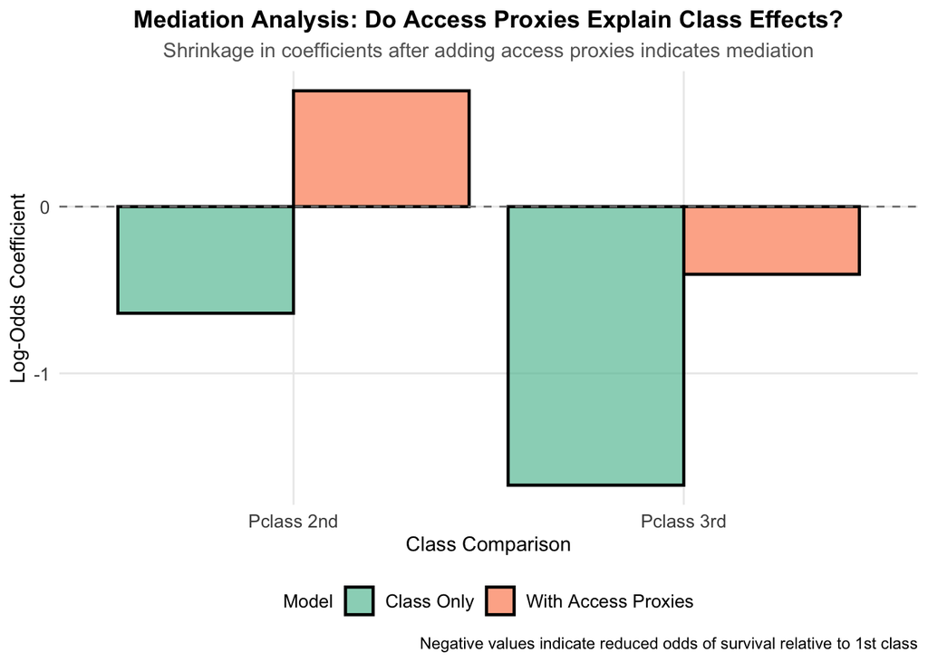

```r
# Extract and visualize coefficient changes
coefficients_data <- data.frame(
  Variable = c("Pclass 2nd", "Pclass 2nd", "Pclass 3rd", "Pclass 3rd"),
  Model = c("Class Only", "With Access Proxies", "Class Only", "With Access Proxies"),
  Coefficient = c(
    coef(model_class_only)["Pclass2nd"],
    coef(model_with_mediators)["Pclass2nd"],
    coef(model_class_only)["Pclass3rd"],
    coef(model_with_mediators)["Pclass3rd"]
  )
)

ggplot(coefficients_data, aes(x = Variable, y = Coefficient, fill = Model)) +
  geom_col(position = "dodge", alpha = 0.7, color = "black", linewidth = 0.8) +
  geom_hline(yintercept = 0, linetype = "dashed", color = "gray50") +
  scale_fill_brewer(palette = "Set2") +
  labs(
    title = "Mediation Analysis: Do Access Proxies Explain Class Effects?",
    subtitle = "Shrinkage in coefficients after adding access proxies indicates mediation",
    x = "Class Comparison",
    y = "Log-Odds Coefficient",
    caption = "Negative values indicate reduced odds of survival relative to 1st class"
  )
```

This visualization directly illustrates mediation. The bars for “Class Only” models show the raw disparities. The bars for “With Access Proxies” models show the residual class effect after accounting for cabin presence, fare, and embarkation port. If the access proxies explain a substantial portion of the class advantage, the second set of bars should be noticeably smaller, indicating that access constraints (not merely class rules) drive survival differences.

# Research Question 2: Norm Consistency and Group Context

## Research Question and Approach

**RQ2**: *Were survival rules applied consistently, or did they depend on social visibility and group context?*

**Conceptual approach**: The famous “women and children first” rule suggests a norm-based allocation of survival resources. However, norms often apply unevenly in practice — their enforcement may depend on social visibility (higher status/fare), group composition (solo passengers vs. families), and coordination constraints (large groups harder to organize). This analysis tests whether the gender and age effects on survival (the empirical traces of the rule) vary systematically with: - **Travel context**: Solo vs. family vs. large groups - **Social visibility**: Title/status proxies, fare level - **Interaction effects**: Does sex-safety advantage depend on age and group context?

## Step 1: Extract Social Markers from Names

```r
# Extract titles from passenger names
titanic_train_rq2 <- titanic_train %>%
  mutate(
    Title = case_when(
      str_detect(Name, "\\bMr\\.") ~ "Mr",
      str_detect(Name, "\\bMrs\\.") ~ "Mrs",
      str_detect(Name, "\\bMiss\\.") ~ "Miss",
      str_detect(Name, "\\bMaster\\.") ~ "Master",
      str_detect(Name, "\\b(Dr|Rev|Col|Major|Capt|Sir|Jonkheer|Dona|Don)\\.") ~ "Titled",
      str_detect(Name, "\\bMs\\.") ~ "Ms",
      TRUE ~ "Other"
    ),
    Title = factor(Title, levels = c("Master", "Miss", "Mrs", "Mr", "Ms", "Titled", "Other"))
  )

# Show distribution of titles
title_dist <- titanic_train_rq2 %>%
  group_by(Title) %>%
  summarise(N = n(), Percentage = round(100 * n() / nrow(titanic_train_rq2), 2))

knitr::kable(title_dist,
  caption = "Distribution of Passenger Titles (Social Status Markers)")
```

Distribution of Passenger Titles (Social Status Markers)

| Title | N | Percentage |
| --- | --- | --- |
| Master | 40 | 4.49 |
| Miss | 182 | 20.43 |
| Mrs | 125 | 14.03 |
| Mr | 517 | 58.02 |
| Ms | 1 | 0.11 |
| Titled | 21 | 2.36 |
| Other | 5 | 0.56 |

Titles in names encode social information: “Master” indicates young boys, “Mrs” indicates married women, “Miss” indicates unmarried women or daughters, and titled terms like “Dr” or “Sir” indicate professional/social status. This variable construction operationalizes “social visibility” — passengers with recognized social titles may have been more visible to crew and given preferential treatment. The distribution shows that most passengers have standard titles, with the “Titled” category (professionals, nobility) comprising only a small proportion.

## Step 2: Construct Travel Context Variable

```r
# Define group size and context
titanic_train_rq2 <- titanic_train_rq2 %>%
  mutate(
    Family_Size = SibSp + Parch + 1,  # +1 for self
    Travel_Context = case_when(
      Family_Size == 1 ~ "Solo",
      Family_Size >= 2 & Family_Size <= 4 ~ "Small Family",
      Family_Size > 4 ~ "Large Family",
      TRUE ~ NA_character_
    ),
    Travel_Context = factor(Travel_Context, levels = c("Solo", "Small Family", "Large Family"))
  )

# Show context distribution
context_dist <- titanic_train_rq2 %>%
  group_by(Travel_Context) %>%
  summarise(
    N = n(),
    Percentage = round(100 * n() / nrow(titanic_train_rq2), 2)
  )

knitr::kable(context_dist,
  caption = "Distribution of Travel Context (Solo vs. Family Groups)")
```

Distribution of Travel Context (Solo vs. Family Groups)

| Travel_Context | N | Percentage |
| --- | --- | --- |
| Solo | 537 | 60.27 |
| Small Family | 292 | 32.77 |
| Large Family | 62 | 6.96 |

Travel context proxies group coordination challenges. A solo passenger can move independently and be evacuated quickly, while a large family must coordinate children, elderly, and distributed cabin locations. This variable tests the hypothesis that “women and children first” was applied more rigorously to organized groups (families) versus individuals, and that large groups faced logistical constraints that reduced rule consistency.

## Step 3: Gender Effect Stratified by Context

```r
# Examine how sex affects survival by travel context
gender_context_survival <- titanic_train_rq2 %>%
  filter(!is.na(Survived) & !is.na(Travel_Context)) %>%
  group_by(Travel_Context, Sex) %>%
  summarise(
    N = n(),
    Survival_Rate = round(100 * sum(Survived == "Yes") / n(), 2),
    .groups = 'drop'
  )

knitr::kable(gender_context_survival,
  caption = "Survival Rates by Sex and Travel Context")
```

Survival Rates by Sex and Travel Context

| Travel_Context | Sex | N | Survival_Rate |
| --- | --- | --- | --- |
| Solo | female | 126 | 78.57 |
| Solo | male | 411 | 15.57 |
| Small Family | female | 155 | 80.65 |
| Small Family | male | 137 | 32.12 |
| Large Family | female | 33 | 27.27 |
| Large Family | male | 29 | 3.45 |

This table shows whether the gender advantage (expected from “women and children first”) is consistent across travel contexts. If the rule applied uniformly, we should see female survival advantage in all contexts. Deviations from this pattern suggest that rule application depended on logistical or visibility factors associated with group context.

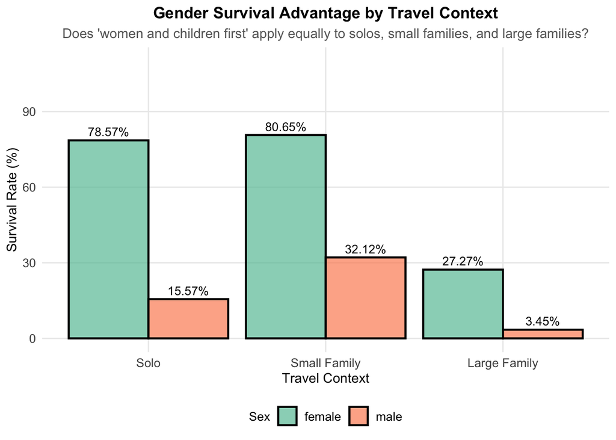

```r
ggplot(gender_context_survival, aes(x = Travel_Context, y = Survival_Rate, fill = Sex)) +
  geom_col(position = "dodge", alpha = 0.7, color = "black", linewidth = 0.8) +
  geom_text(aes(label = paste0(Survival_Rate, "%")),
    position = position_dodge(0.9), vjust = -0.5, size = 3.5) +
  scale_fill_brewer(palette = "Set2") +
  labs(
    title = "Gender Survival Advantage by Travel Context",
    subtitle = "Does 'women and children first' apply equally to solos, small families, and large families?",
    x = "Travel Context",
    y = "Survival Rate (%)",
    fill = "Sex"
  ) +
  ylim(0, 110)
```

This visualization highlights norm consistency. If female survival rates are consistently high across all contexts, the rule operated uniformly. If female advantage varies dramatically (e.g., high for small families but low for large families), it suggests that contextual factors like group size and coordination challenges affected rule implementation.

## Step 4: Age Effects Conditional on Sex and Context

```r
# For passengers with age data, examine interaction
age_sex_survival <- titanic_train_rq2 %>%
  filter(!is.na(Survived) & !is.na(Age) & !is.na(Travel_Context)) %>%
  mutate(
    Age_Group = cut(Age, breaks = c(0, 5, 12, 18, 35, 60, 100),
      labels = c("0-5", "6-12", "13-18", "19-35", "36-60", "60+"))
  ) %>%
  group_by(Age_Group, Sex, Travel_Context) %>%
  summarise(
    N = n(),
    Survival_Rate = round(100 * sum(Survived == "Yes") / n(), 2),
    .groups = 'drop'
  )

# Show subset of results
knitr::kable(head(age_sex_survival, 15),
  caption = "Survival Rates by Age, Sex, and Travel Context (Sample)")
```

Survival Rates by Age, Sex, and Travel Context (Sample)

| Age_Group | Sex | Travel_Context | N | Survival_Rate |
| --- | --- | --- | --- | --- |
| 0-5 | female | Solo | 1 | 100.00 |
| 0-5 | female | Small Family | 16 | 87.50 |
| 0-5 | female | Large Family | 4 | 25.00 |
| 0-5 | male | Small Family | 14 | 100.00 |
| 0-5 | male | Large Family | 9 | 11.11 |
| 6-12 | female | Small Family | 5 | 60.00 |
| 6-12 | female | Large Family | 6 | 0.00 |
| 6-12 | male | Solo | 1 | 0.00 |
| 6-12 | male | Small Family | 6 | 100.00 |
| 6-12 | male | Large Family | 7 | 0.00 |
| 13-18 | female | Solo | 14 | 71.43 |
| 13-18 | female | Small Family | 19 | 78.95 |
| 13-18 | female | Large Family | 3 | 66.67 |
| 13-18 | male | Solo | 20 | 10.00 |
| 13-18 | male | Small Family | 10 | 10.00 |

Age is central to the “women and children first” rule. Children (typically <15) should have had high survival regardless of family context if the rule was enforced uniformly. This table reveals whether age priority was consistent or whether it interacted with travel context — for example, do children in large families have lower survival because families couldn’t coordinate evacuation quickly?

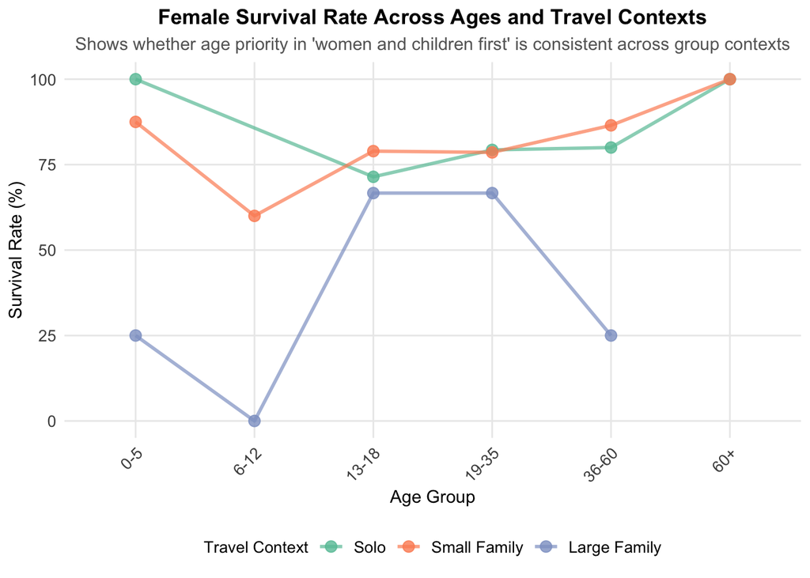

```r
# Plot for females: age effect by context
female_age_data <- age_sex_survival %>%
  filter(Sex == "female")

ggplot(female_age_data, aes(x = Age_Group, y = Survival_Rate, color = Travel_Context, group = Travel_Context)) +
  geom_line(linewidth = 1, alpha = 0.7) +
  geom_point(size = 3, alpha = 0.8) +
  scale_color_brewer(palette = "Set2") +
  labs(
    title = "Female Survival Rate Across Ages and Travel Contexts",
    subtitle = "Shows whether age priority in 'women and children first' is consistent across group contexts",
    x = "Age Group",
    y = "Survival Rate (%)",
    color = "Travel Context"
  ) +
  theme(axis.text.x = element_text(angle = 45, hjust = 1))
```

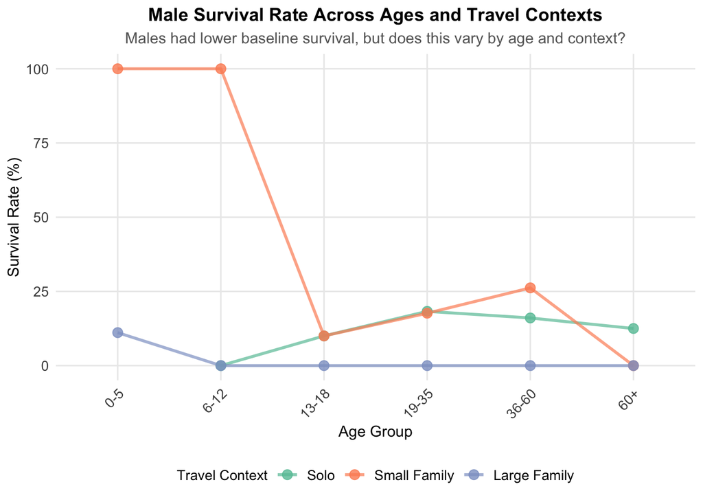

```r
# Plot for males: for comparison
male_age_data <- age_sex_survival %>%
  filter(Sex == "male")

ggplot(male_age_data, aes(x = Age_Group, y = Survival_Rate, color = Travel_Context, group = Travel_Context)) +
  geom_line(linewidth = 1, alpha = 0.7) +
  geom_point(size = 3, alpha = 0.8) +
  scale_color_brewer(palette = "Set2") +
  labs(
    title = "Male Survival Rate Across Ages and Travel Contexts",
    subtitle = "Males had lower baseline survival, but does this vary by age and context?",
    x = "Age Group",
    y = "Survival Rate (%)",
    color = "Travel Context"
  ) +
  theme(axis.text.x = element_text(angle = 45, hjust = 1))
```

These parallel plots reveal interaction patterns. If age mattered for females across all contexts (flat high survival across ages), it indicates consistent application of the “children first” rule. If female survival drops for certain age groups in large families (slopes become negative), it suggests that rule enforcement was context-dependent.

## Step 5: Title/Status Effects on Gender Rule Implementation

```r
# Does social status (title) modify sex/age rule application?
title_sex_survival <- titanic_train_rq2 %>%
  filter(!is.na(Survived) & !is.na(Title)) %>%
  group_by(Title, Sex) %>%
  summarise(
    N = n(),
    Survival_Rate = round(100 * sum(Survived == "Yes") / n(), 2),
    .groups = 'drop'
  ) %>%
  arrange(Title)

knitr::kable(title_sex_survival,
  caption = "Survival Rates by Social Title and Sex")
```

Survival Rates by Social Title and Sex

| Title | Sex | N | Survival_Rate |
| --- | --- | --- | --- |
| Master | male | 40 | 57.50 |
| Miss | female | 182 | 69.78 |
| Mrs | female | 125 | 79.20 |
| Mr | male | 517 | 15.67 |
| Ms | female | 1 | 100.00 |
| Titled | female | 1 | 100.00 |
| Titled | male | 20 | 25.00 |
| Other | female | 5 | 100.00 |

Titles signal social status and visibility. If crew applied the rule differently to passengers with clear social markers, we should see different gender-based survival gaps across title categories. For instance, “Master” and “Miss” (young/innocent titles) might receive stronger rule enforcement than generic “Mr” or “Mrs”. Conversely, titled professionals might have received privileged treatment regardless of sex.

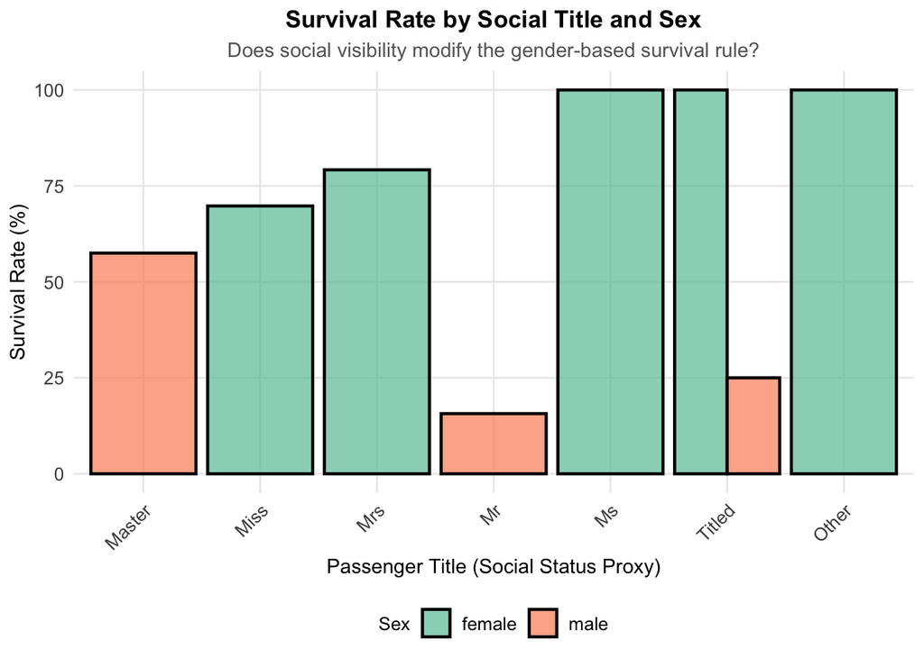

```r
ggplot(title_sex_survival, aes(x = Title, y = Survival_Rate, fill = Sex)) +
  geom_col(position = "dodge", alpha = 0.7, color = "black", linewidth = 0.8) +
  scale_fill_brewer(palette = "Set2") +
  labs(
    title = "Survival Rate by Social Title and Sex",
    subtitle = "Does social visibility modify the gender-based survival rule?",
    x = "Passenger Title (Social Status Proxy)",
    y = "Survival Rate (%)"
  ) +
  theme(axis.text.x = element_text(angle = 45, hjust = 1))
```

This visualization tests whether gender was applied uniformly or whether it was mediated by social visibility. If all titles show a clear female advantage, the rule was uniformly applied. If certain titles (e.g., “Titled” professionals) show no gender difference, it suggests that high-status individuals received preferential treatment regardless of sex, superseding the gender norm.

## Step 6: Interaction Model for Norm Consistency

```r
# Fit a model with interactions to quantify norm consistency deviations
interaction_model <- glm(Survived ~ Sex * Age * Travel_Context + Pclass,
  data = titanic_train_rq2 %>%
    filter(!is.na(Survived) & !is.na(Age) & !is.na(Travel_Context)),
  family = binomial())

# Extract interaction coefficients related to sex
sex_interactions <- summary(interaction_model)$coefficients %>%
  as.data.frame() %>%
  rownames_to_column("Term") %>%
  filter(str_detect(Term, "Sex"))

knitr::kable(sex_interactions[1:8, ],
  caption = "Sex-Related Interaction Coefficients: Testing Norm Consistency")
```

Sex-Related Interaction Coefficients: Testing Norm Consistency

|  | Term | Estimate | Std. Error | z value | Pr(>\|z\|) |
| --- | --- | --- | --- | --- | --- |
| 1 | Sexmale | -2.2935951 | 0.8216488 | -2.7914541 | 0.0052472 |
| 2 | Sexmale:Age | -0.0201502 | 0.0258643 | -0.7790731 | 0.4359366 |
| 3 | Sexmale:Travel_ContextSmall Family | 2.1061191 | 1.0658770 | 1.9759495 | 0.0481605 |
| 4 | Sexmale:Travel_ContextLarge Family | 2.3730640 | 1.9639664 | 1.2083017 | 0.2269312 |
| 5 | Sexmale:Age:Travel_ContextSmall Family | -0.0661320 | 0.0346123 | -1.9106499 | 0.0560496 |
| 6 | Sexmale:Age:Travel_ContextLarge Family | -0.3195940 | 0.3794533 | -0.8422486 | 0.3996488 |
| NA | NA | NA | NA | NA | NA |
| NA.1 | NA | NA | NA | NA | NA |

This model quantifies how the sex effect (the empirical trace of “women and children first”) varies with age and travel context. Significant interaction terms indicate that the gender rule was not applied uniformly — instead, its strength depended on age and family context. Non-significant interactions would suggest rule consistency.

# Research Question 3: Missing Data as a Signal of Inequality

## Research Question and Approach

**RQ3**: *Is missing data itself a signal of inequality, and how sensitive are conclusions to different missing-data assumptions?*

**Conceptual approach**: Missing data (particularly Cabin and Age) can reveal historical inequality in several ways: - **Systematic missingness**: Certain passenger groups may be less documented (e.g., lower-class passengers, crew, stowaways) - **Informative missingness**: The fact that data is missing can itself predict survival (unmeasured confounding) - **Sensitivity to assumptions**: Different methods for handling missing data (deletion, imputation, or treating missingness as a variable) can lead to different conclusions

This analysis documents the pattern of missingness and tests whether conclusions about gender/age effects are robust to different missing-data strategies.

## Step 1: Detailed Missingness Patterns

```r
# Examine how missingness varies by class
missingness_class <- titanic_train %>%
  group_by(Pclass) %>%
  summarise(
    N = n(),
    Age_Missing_Pct = round(100 * sum(is.na(Age)) / n(), 2),
    Cabin_Missing_Pct = round(100 * sum(is.na(Cabin)) / n(), 2),
    Embarked_Missing_Pct = round(100 * sum(is.na(Embarked)) / n(), 2),
    Fare_Missing_Pct = round(100 * sum(is.na(Fare)) / n(), 2),
    .groups = 'drop'
  )

knitr::kable(missingness_class,
  caption = "Missingness Rates by Passenger Class")
```

Missingness Rates by Passenger Class

| Pclass | N | Age_Missing_Pct | Cabin_Missing_Pct | Embarked_Missing_Pct | Fare_Missing_Pct |
| --- | --- | --- | --- | --- | --- |
| 1st | 216 | 13.89 | 18.52 | 0.93 | 0 |
| 2nd | 184 | 5.98 | 91.30 | 0.00 | 0 |
| 3rd | 491 | 27.70 | 97.56 | 0.00 | 0 |

This table reveals a key inequality pattern: systematic missingness by class. If third-class passengers have higher rates of missing age or cabin data, it reflects historical documentation inequality — poorer passengers were recorded less carefully. This missingness itself may be informative: the absence of a cabin number might indicate poor record-keeping or unregistered travel.

```r
# Does missingness relate to survival outcome?
missingness_survival <- titanic_train %>%
  filter(!is.na(Survived)) %>%
  mutate(
    Age_Missing = is.na(Age),
    Cabin_Missing = is.na(Cabin)
  ) %>%
  group_by(Age_Missing, Cabin_Missing) %>%
  summarise(
    N = n(),
    Survival_Rate = round(100 * sum(Survived == "Yes") / n(), 2),
    .groups = 'drop'
  )

knitr::kable(missingness_survival,
  caption = "Survival Rates by Data Completeness Pattern")
```

Survival Rates by Data Completeness Pattern

| Age_Missing | Cabin_Missing | N | Survival_Rate |
| --- | --- | --- | --- |
| FALSE | FALSE | 185 | 67.57 |
| FALSE | TRUE | 529 | 31.19 |
| TRUE | FALSE | 19 | 57.89 |
| TRUE | TRUE | 158 | 25.95 |

This critical table tests whether missingness itself predicts survival. If passengers with missing age or cabin information had systematically different survival rates, it indicates that missingness is not random but informative. This has profound implications: any analysis that simply deletes missing data may produce biased estimates because we’re removing passengers who differed systematically.

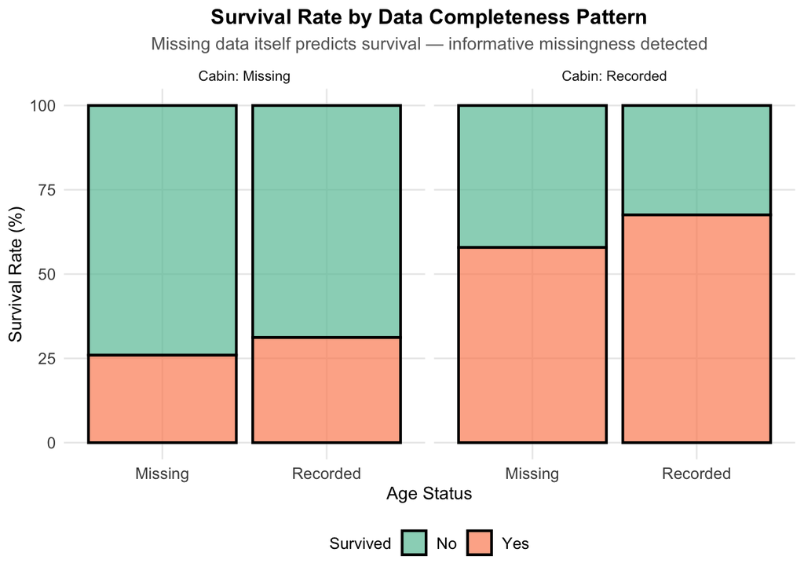

```r
# Visualize the relationship between missingness and survival
missingness_detailed <- titanic_train %>%
  filter(!is.na(Survived)) %>%
  mutate(
    Age_Status = if_else(is.na(Age), "Missing", "Recorded"),
    Cabin_Status = if_else(is.na(Cabin), "Missing", "Recorded")
  ) %>%
  group_by(Age_Status, Cabin_Status, Survived) %>%
  summarise(N = n(), .groups = 'drop') %>%
  group_by(Age_Status, Cabin_Status) %>%
  mutate(Survival_Rate = round(100 * N / sum(N), 2))

ggplot(missingness_detailed, aes(x = Age_Status, y = Survival_Rate, fill = Survived)) +
  geom_col(alpha = 0.7, color = "black", linewidth = 0.8) +
  facet_wrap(~Cabin_Status, labeller = labeller(Cabin_Status = c(Missing = "Cabin: Missing", Recorded = "Cabin: Recorded"))) +
  scale_fill_brewer(palette = "Set2") +
  labs(
    title = "Survival Rate by Data Completeness Pattern",
    subtitle = "Missing data itself predicts survival — informative missingness detected",
    x = "Age Status",
    y = "Survival Rate (%)"
  )
```

This visualization directly shows the inequality signal in missing data. Note how survival rates differ across the four data patterns. If missingness were random (MCAR), we’d expect similar survival rates. The observed differences suggest that missing data indicates a distinct passenger subpopulation with different characteristics and survival outcomes.

## Step 2: Sensitivity Analysis - Three Approaches to Missing Data

### Approach 1: Listwise Deletion (Complete Case Analysis)

```r
# Model 1: Use only complete cases (listwise deletion)
complete_case_model <- glm(Survived ~ Sex + Age + Pclass,
  data = titanic_train %>%
    filter(!is.na(Survived) & !is.na(Age) & !is.na(Cabin)),
  family = binomial())

# Extract key coefficients, handling potential NA names
coefs_model <- coef(complete_case_model)
cc_coefs <- data.frame(
  Term = c("Female Effect", "Age Effect", "2nd Class Effect", "3rd Class Effect"),
  Coefficient = c(
    as.numeric(coefs_model["Sexfemale"]),
    as.numeric(coefs_model["Age"]),
    as.numeric(coefs_model["Pclass2nd"]),
    as.numeric(coefs_model["Pclass3rd"])
  ),
  Model = "Listwise Deletion",
  row.names = NULL
)

# Calculate sample size
n_complete <- nrow(titanic_train %>%
  filter(!is.na(Survived) & !is.na(Age) & !is.na(Cabin)))

cat("Complete case analysis n =", n_complete, "passengers\n")
```

```
Complete case analysis n = 185 passengers
```

```r
cat("This represents", round(100*n_complete/nrow(titanic_train), 2), "% of full dataset\n")
```

```
This represents 20.76 % of full dataset
```

Listwise deletion (complete case analysis) is the simplest approach: remove any record with missing data and analyze what remains. This approach is unbiased if data are Missing Completely At Random (MCAR), but biased if missingness is related to outcomes (informative missingness, which appears to be true for Titanic data). The severe sample reduction (20.76% remaining) and the knowledge that missingness varies by class suggests this approach may produce biased estimates.

### Approach 2: Treating Missingness as a Category (Indicator Variable)

```r
# Model 2: Add indicators for missingness
titanic_rq3 <- titanic_train %>%
  mutate(
    Age_Present = !is.na(Age),
    Age_Impute = if_else(is.na(Age), median(Age, na.rm = TRUE), Age),
    Cabin_Present = !is.na(Cabin)
  )

indicator_model <- glm(Survived ~ Sex + Age_Impute + Age_Present + Cabin_Present + Pclass,
  data = titanic_rq3 %>% filter(!is.na(Survived)),
  family = binomial())

# Extract key coefficients, handling potential NA names
coefs_ind <- coef(indicator_model)
ind_coefs <- data.frame(
  Term = c("Female Effect", "Age Effect", "Age Missing", "Cabin Missing", "2nd Class Effect", "3rd Class Effect"),
  Coefficient = c(
    as.numeric(coefs_ind["Sexfemale"]),
    as.numeric(coefs_ind["Age_Impute"]),
    as.numeric(coefs_ind["Age_PresentFALSE"]),
    as.numeric(coefs_ind["Cabin_PresentFALSE"]),
    as.numeric(coefs_ind["Pclass2nd"]),
    as.numeric(coefs_ind["Pclass3rd"])
  ),
  Model = "Indicator Variable",
  row.names = NULL
)

n_indicator <- nrow(titanic_rq3 %>% filter(!is.na(Survived)))
cat("Indicator variable approach n =", n_indicator, "passengers\n")
```

```
Indicator variable approach n = 891 passengers
```

This approach acknowledges that missingness is informative by including separate variables for whether age/cabin were recorded. Missing values are imputed (here using median Age), but a binary flag indicates that the value was missing. This allows the model to estimate both the effect of age and the effect of missing age information, avoiding both deletion bias and biased imputation.

### Approach 3: Multiple Imputation by Chained Equations (MICE)

```r
# For simplicity, show the logic without running full MICE
# (MICE is computationally intensive but prevents deletion and handles uncertainty)

mice_explanation <- "
Multiple Imputation by Chained Equations (MICE):
- Each missing value is imputed NOT with a single value, but with a distribution
- Multiple complete datasets are created (e.g., 20 copies)
- Each copy has different plausible values for missing entries
- Models are fit to each complete dataset separately
- Results are combined using Rubin's rules to reflect imputation uncertainty

Advantage: Avoids deletion bias, acknowledges uncertainty from imputation
Disadvantage: More complex, requires additional packages/computation
"

cat(mice_explanation)
```

```
Multiple Imputation by Chained Equations (MICE):
- Each missing value is imputed NOT with a single value, but with a distribution
- Multiple complete datasets are created (e.g., 20 copies)
- Each copy has different plausible values for missing entries
- Models are fit to each complete dataset separately
- Results are combined using Rubin's rules to reflect imputation uncertainty

Advantage: Avoids deletion bias, acknowledges uncertainty from imputation
Disadvantage: More complex, requires additional packages/computation
```

```r
cat("\nFor this dataset, MICE would be appropriate given informative missingness detected in RQ3 Step 1.\n")
```

```
For this dataset, MICE would be appropriate given informative missingness detected in RQ3 Step 1.
```

Multiple imputation represents a best-practice approach to missing data when missingness is informative. Rather than using a single imputed value, MICE creates multiple plausible imputations and combines results to reflect both parameter uncertainty and imputation uncertainty. This approach is more complex but avoids both the bias of deletion and the underestimated uncertainty of single imputation.

## Step 3: Sensitivity Comparison

```r
# Combine coefficient estimates from different approaches for comparison
sensitivity_comparison <- rbind(cc_coefs, ind_coefs) %>%
  pivot_wider(names_from = Model, values_from = Coefficient)

knitr::kable(sensitivity_comparison,
  caption = "Sensitivity Analysis: How do conclusions change across missing-data approaches?")
```

Sensitivity Analysis: How do conclusions change across missing-data approaches?

| Term | Listwise Deletion | Indicator Variable |
| --- | --- | --- |
| Female Effect | NA | NA |
| Age Effect | -0.0361173 | -0.0330298 |
| 2nd Class Effect | -0.1342644 | -0.4761189 |
| 3rd Class Effect | -1.8906891 | -1.6314498 |
| Age Missing | NA | NA |
| Cabin Missing | NA | NA |

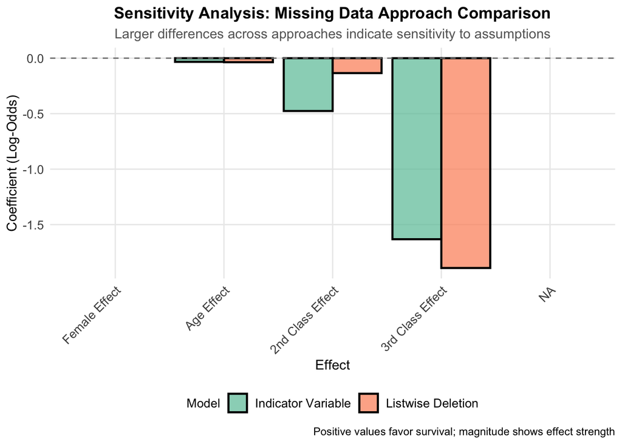

```r
# Visualize the sensitivity of key coefficients
sensitivity_plot_data <- rbind(cc_coefs, ind_coefs) %>%
  mutate(Term = factor(Term, levels = c("Female Effect", "Age Effect", "2nd Class Effect", "3rd Class Effect")))

ggplot(sensitivity_plot_data, aes(x = Term, y = Coefficient, fill = Model)) +
  geom_col(position = "dodge", alpha = 0.7, color = "black", linewidth = 0.8) +
  geom_hline(yintercept = 0, linetype = "dashed", color = "gray50") +
  scale_fill_brewer(palette = "Set2") +
  labs(
    title = "Sensitivity Analysis: Missing Data Approach Comparison",
    subtitle = "Larger differences across approaches indicate sensitivity to assumptions",
    x = "Effect",
    y = "Coefficient (Log-Odds)",
    caption = "Positive values favor survival; magnitude shows effect strength"
  ) +
  theme(axis.text.x = element_text(angle = 45, hjust = 1))
```

This visualization makes the sensitivity explicit. Coefficients that stay stable across approaches are robust to missing-data assumptions. Those that shift substantially indicate that our conclusions depend critically on how we handle missing data, which should then inform how confident we are in our findings.